# Differential Expression

Harvard Chan Bioinformatics Core

2024-05-22

```r
# 1. Set up input files in this R file (params_de.R)
source(params$params_file)
# 2. Set up project file (already done from QC probably)
source(params$project_file)
# 3. Load custom functions to load data from coldata/metrics/counts
source(params$functions_file)
# IMPORTANT set these values if you are not using the parameters at the top
genome=params$genome
column=params$column
numerator=params$numerator
denominator=params$denominator
subset_column=params$subset_column
subset_value=params$subset_value
run_ruv=params$ruv
```

```r
library(rtracklayer)
library(DESeq2)
library(tidyverse)
library(stringr)
library(RUVSeq)
library(DEGreport)
library(ggpubr)
library(msigdbr)
library(fgsea)
library(org.Hs.eg.db)
library(knitr)
library(EnhancedVolcano)
library(bcbioR)
library(ggprism)
library(viridis)
library(pheatmap)
library(janitor)
colors=cb_friendly_cols(1:15)
ggplot2::theme_set(theme_prism(base_size = 14))
opts_chunk[["set"]](
    cache = F,
    cache.lazy = FALSE,
    dev = c("png", "pdf"),
    error = TRUE,
    highlight = TRUE,
    message = FALSE,
    prompt = FALSE,
    tidy = FALSE,
    warning = FALSE,
    echo = T,
    fig.height = 4)

# set seed for reproducibility
set.seed(1234567890L)
```

```r
# This code will load from bcbio or nf-core folder
# NOTE make sure to set numerator and denominator
coldata <- load_coldata(coldata_fn, column,
                        numerator, denominator,
                        subset_column, subset_value)
coldata$sample=row.names(coldata)

counts <- load_counts(counts_fn)
counts <- counts[,colnames(counts) %in% coldata$sample]

metrics <- load_metrics(se_object, multiqc_data_dir, gtf_fn, counts) %>%
  left_join(coldata, by = c('sample')) %>%
  as.data.frame()
rownames(metrics) <- metrics$sample
# if the names don't match in order or string check files names and coldata information
counts = counts[rownames(metrics)]
coldata = coldata[rownames(metrics),]
stopifnot(all(names(counts) == rownames(metrics)))
```

```r
sanitize_datatable = function(df, ...) {
 # remove dashes which cause wrapping
 DT::datatable(df, ..., rownames=gsub("-", "_", rownames(df)),
                   colnames=gsub("-", "_", colnames(df)))
}
```

# 1 Overview

```r
if (!is.null(subset_value) & !is.null(subset_value)){
  filenames = str_interp("${subset_value}_${numerator}_vs_${denominator}")
} else {
  filenames = str_interp("${numerator}_vs_${denominator}")
}

contrasts = c(column,numerator,denominator)
coef=paste0(column,"_",numerator,"_vs_",denominator)

name_expression_fn=file.path(
                             basedir,
                             str_interp("${filenames}_expression.csv"))
name_deg_fn=file.path(
                      basedir,
                      str_interp("${filenames}_deg.csv"))
name_pathways_fn=file.path(
                           basedir,
                           str_interp("${filenames}_pathways.csv"))
```

```r
rdata = AnnotationDbi::select(org.Hs.eg.db, rownames(counts), 'SYMBOL', 'ENSEMBL') %>%
  dplyr::select(gene_id = ENSEMBL, gene_name = SYMBOL)
```

```r
dds_to_use <- DESeqDataSetFromMatrix(counts, coldata, design = ~1)

vsd_before <- vst(dds_to_use)
norm_matrix = assay(vsd_before)
```

# 2 Covariate analysis

```r
degCovariates(
  norm_matrix,
  metrics,
)
```

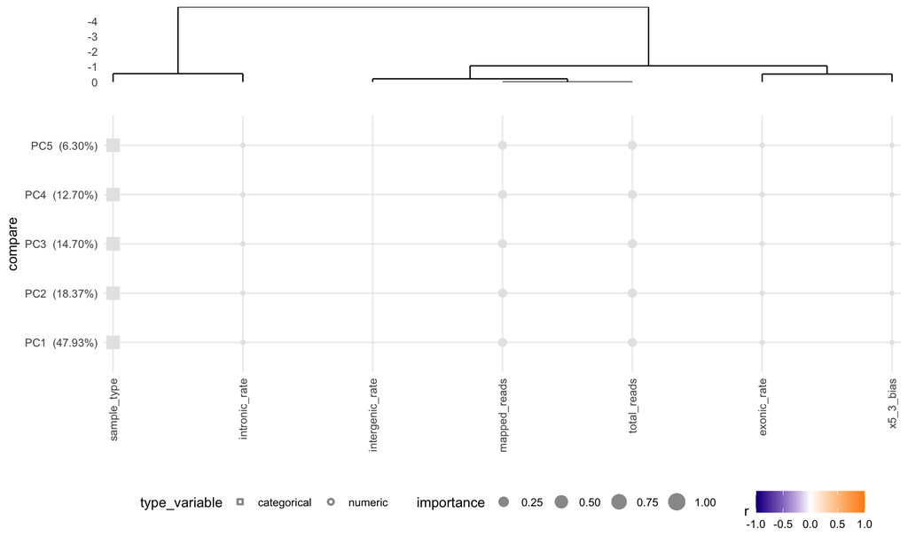

# 3 PCA analysis

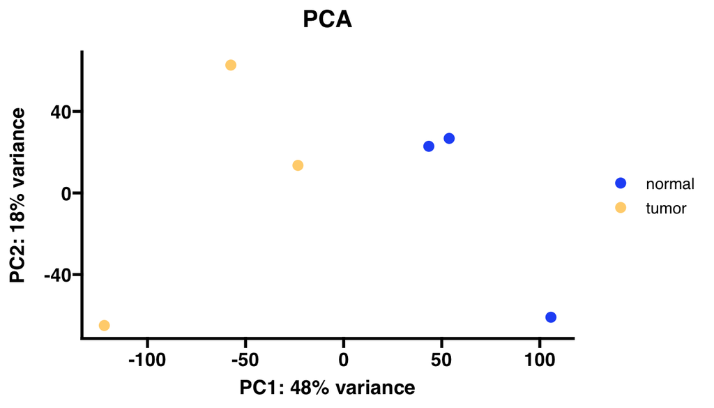

```r
pca1 <- degPCA(norm_matrix, colData(dds_to_use),
       condition = column) + ggtitle('PCA')
pca1 + scale_color_cb_friendly()
```

```r
formula <- as.formula(paste0("~ ", " + ", column))
## Check if sample name matches
stopifnot(all(names(counts) == rownames(coldata)))

dds_to_use <- DESeqDataSetFromMatrix(counts, coldata, design = formula)

vsd_before <- vst(dds_to_use)
norm_matrix = assay(vsd_before)
new_cdata <- coldata
```

```r
# If you want to skip the code, just set up formula to be your model in the next chunk of code
design <- coldata[[column]]
diffs <- makeGroups(design)
dat <- norm_matrix
ruvset <- RUVs(dat, cIdx=rownames(dat), k=1, diffs, isLog = T, round = F)
vars <- ruvset$W

new_cdata <- cbind(coldata, vars)

formula <- as.formula(paste0("~ ",
                          paste0(
                            colnames(new_cdata)[grepl("W", colnames(new_cdata))],
                            collapse = " + "
                          ), " + ", column)
)
norm_matrix=ruvset$normalizedCounts
pca2 <- degPCA(norm_matrix, new_cdata,
       condition = column) + ggtitle('After RUV')
pca2 + scale_color_cb_friendly()
```

[output not shown]

```r
dds_to_use <- DESeqDataSetFromMatrix(counts, new_cdata, design = formula)
vsd_to_use<- vst(dds_to_use, blind=FALSE)
```

# 4 Differential Expression

Differential gene expression analysis of count data was performed using the Bioconductor R package, DESeq2, which fits the count data to a negative binomial model.

Before fitting the model, we often look at a metric called dispersion, which is a measure for variance which also takes into consideration mean expression. A dispersion value is estimated for each individual gene, then ‘shrunken’ to a more accurate value based on expected variation for a typical gene exhibiting that level of expression. Finally, the shrunken dispersion value is used in the final GLM fit.

We use the below dispersion plot, which should show an inverse relationship between dispersion and mean expression, to get an idea of whether our data is a good fit for the model.

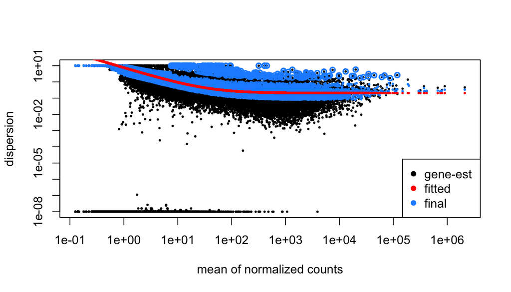

```r
de <- DESeq(dds_to_use)

DESeq2::plotDispEsts(de)
```

Because it is difficult to accurately detect and quantify the expression of lowly expressed genes, differences in their expression between treatment conditions can be unduly exaggerated after the model is fit. We correct for this so that gene LFC is not dependent overall on basal gene expression level.

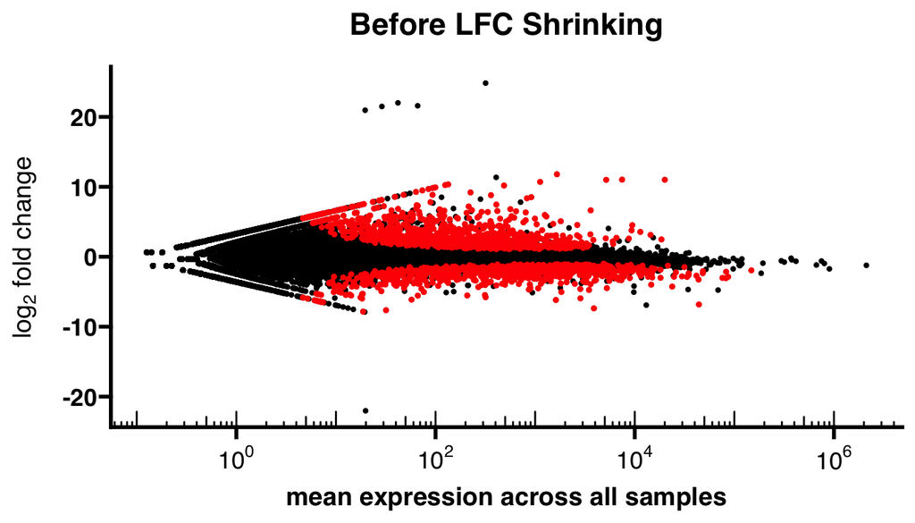

```r
# resultsNames(de) # check the order is right
resLFC = results(de, contrast=contrasts)
resLFCS <- lfcShrink(de, coef=coef, type="apeglm")

res <- as.data.frame(resLFCS) %>%
  rownames_to_column('gene_id') %>% left_join(rdata, by = 'gene_id') %>%
  relocate(gene_name) %>% dplyr::rename(lfc = log2FoldChange) %>%
  mutate(pi = abs(lfc) * -log10(padj)) %>% arrange(-pi)

res_sig <- res %>% filter(padj < 0.05) %>% arrange(padj) %>%
  mutate(gene_name = ifelse(is.na(gene_name), gene_id, gene_name))

res_mod <- res %>% mutate(lfc = replace(lfc, lfc < -5, -5)) %>% mutate(lfc = replace(lfc, lfc > 5, 5))
show <- as.data.frame(res_mod[1:10, c("lfc", "padj", "gene_name")])

degMA(as.DEGSet(resLFC)) + ggtitle('Before LFC Shrinking')
```

## 4.1 MA plot

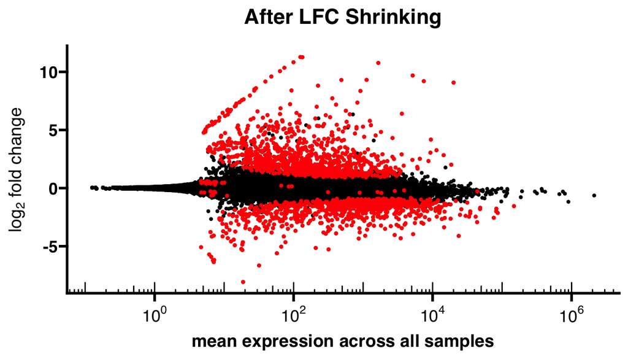

```r
degMA(as.DEGSet(resLFCS), limit = 2) + ggtitle('After LFC Shrinking')
```

## 4.2 Volcano plot

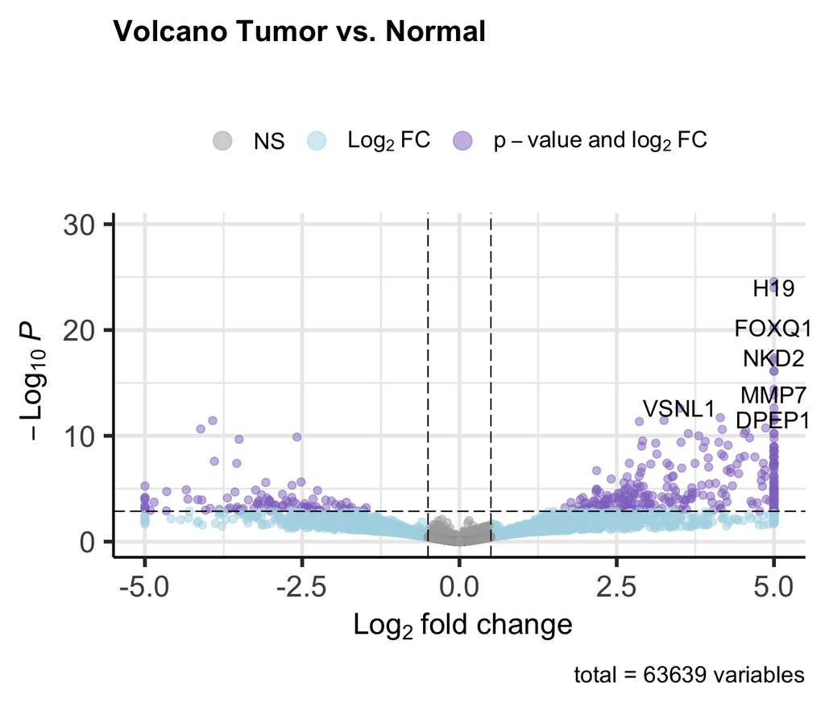

```r
# degVolcano(res_mod[,c('lfc', 'padj')], plot_text = show)
EnhancedVolcano(res_mod,
                lab= res_mod$gene_name,
                pCutoff = 1.345719e-03,
                selectLab = c(res_sig$gene_name[1:15]),
                FCcutoff = 0.5,
                x = 'lfc',
                y = 'padj',
                title="Volcano Tumor vs. Normal",
                col=as.vector(colors[c("dark_grey", "light_blue",
                                         "purple", "purple")]),
                subtitle = "", xlim=c(-5,5))
```

## 4.3 Heatmap

```r
### Run pheatmap using the metadata data frame for the annotation
ma=norm_matrix[res_sig$gene_id,]
colma=coldata[,c(column), drop=FALSE]
colors=lapply(colnames(colma), function(c){
  l.col=colors[1:length(unique(colma[[c]]))]
  names(l.col)=unique(colma[[c]])
  l.col
})
names(colors)=colnames(colma)
pheatmap(ma,
         color = inferno(10),
         cluster_rows = T,
         show_rownames = F,
         annotation = colma,
         annotation_colors = colors,
         border_color = NA,
         fontsize = 10,
         scale = "row",
         fontsize_row = 10,
         height = 20)
```

[output not shown]

## 4.4 Differentially Expressed Genes

```r
res_sig %>% sanitize_datatable
```

|  | gene_name | gene_id | baseMean | lfc | lfcSE | pvalue | padj | pi |
| --- | --- | --- | --- | --- | --- | --- | --- | --- |
| 1 | CLDN1 | ENSG00000163347 | 803.2200455135329 | 5.130425193713816 | 0.4645770921040143 | 1.252807569248759e-29 | 2.581785838707842e-25 | 126.1473039974243 |
| 2 | H19 | ENSG00000130600 | 578.86920883679 | 5.704803596895576 | 0.5234863239449783 | 9.607081965648636e-29 | 9.899137257404353e-25 | 136.9404026016153 |
| 3 | FOXQ1 | ENSG00000164379 | 914.6589169747284 | 8.355966247273857 | 0.837897353202882 | 8.866747237044413e-25 | 6.090864235367042e-21 | 168.9185406286558 |
| 4 | NKD2 | ENSG00000145506 | 290.1237128485038 | 6.273454218392652 | 0.6750025538723818 | 8.51194195868327e-22 | 4.385352497113621e-18 | 108.8945900424971 |
| 5 | NKD1 | ENSG00000140807 | 546.7992273556806 | 5.192169122741017 | 0.5625770031267104 | 1.760213506619533e-21 | 7.254895988883066e-18 | 88.9905015160722 |
| 6 | INHBA | ENSG00000122641 | 563.954125480642 | 6.651627198240175 | 0.7433719132826634 | 2.389897491657802e-20 | 7.738618094138037e-17 | 107.1666046323004 |
| 7 | KRT23 | ENSG00000108244 | 642.9849856652712 | 6.352368112211839 | 0.7126879289431345 | 2.628606689584931e-20 | 7.738618094138037e-17 | 102.3451407710204 |
| 8 | GRIN2D | ENSG00000105464 | 217.2393258194219 | 5.363753496957825 | 0.6344755614954621 | 1.532858194339786e-18 | 3.948642708619289e-15 | 77.25710327459655 |
| 9 | MMP7 | ENSG00000137673 | 215.0043512985642 | 7.0013064359399 | 0.8358827342921575 | 5.803844477466334e-18 | 1.328951411018069e-14 | 97.15356502820173 |
| 10 | SLC13A3 | ENSG00000158296 | 119.2290230955865 | 5.846457662636544 | 0.728351811729779 | 1.175720233523794e-16 | 2.422924257245835e-13 | 73.75692302380955 |

[output cut: 1966 more lines]

## 4.5 Plot top 16 genes

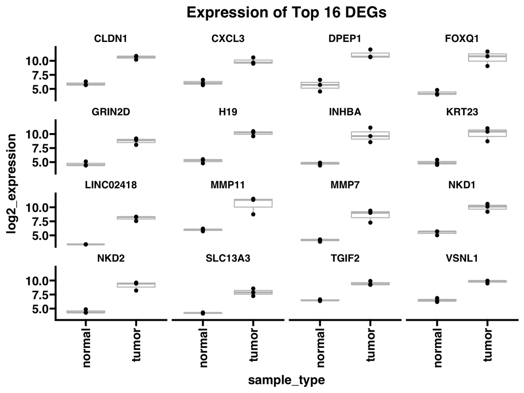

```r
n = 16
top_n <- res_sig %>% slice_min(order_by = padj, n = n, with_ties = F) %>%
  dplyr::select(gene_name, gene_id)
top_n_exp <- norm_matrix %>% as.data.frame() %>%
  rownames_to_column('gene_id') %>%
  # dplyr::select(-group, -group_name) %>%
  pivot_longer(!gene_id, names_to = 'sample', values_to = 'log2_expression') %>%
  right_join(top_n, relationship = "many-to-many") %>%
  left_join(coldata, by = 'sample')

ggplot(top_n_exp, aes_string(x = column, y = 'log2_expression')) +
  geom_boxplot(outlier.shape = NA, linewidth=0.5, color="grey") +
  geom_point() +
  facet_wrap(~gene_name) +
  ggtitle(str_interp('Expression of Top ${n} DEGs')) +
  theme(axis.text.x = element_text(angle = 90, vjust = 0.5, hjust=1))
```

# 5 Pathway Enrichment

From the set of differentially expressed genes and using publicly available information about gene sets involved in biological processes and functions, we can calculate which biological processes and functions are significantly perturbed as a result of the treatment.

```r
universe=res %>%
  filter(!is.na(padj)) %>% pull(gene_id)
mapping = AnnotationDbi::select(org.Hs.eg.db, universe, 'ENTREZID', 'ENSEMBL')

all_in_life=list(
  msigdbr(species = "human", category = "H") %>% mutate(gs_subcat="Hallmark"),
  msigdbr(species = "human", category = "C2", subcategory = "CP:REACTOME"),
  msigdbr(species = "human", category = "C2", subcategory = "CP:KEGG"),
  msigdbr(species = "human", category = "C2", subcategory = "CP:PID"),
  msigdbr(species = "human", category = "C5", subcategory = "GO:BP"),
  msigdbr(species = "human", category = "C5", subcategory = "GO:MF"),
  msigdbr(species = "human", category = "C5", subcategory = "HPO"),
  msigdbr(species = "human", category = "C3", subcategory = "TFT:GTRD"),
  msigdbr(species = "human", category = "C6") %>% mutate(gs_subcat="Oncogenic")
)

ora_input = res %>% filter(!is.na(padj), padj<0.01, abs(lfc)>0.3) %>% pull(gene_id)
input_entrezid <- AnnotationDbi::select(org.Hs.eg.db, ora_input, 'ENSEMBL', columns = c('ENTREZID', 'SYMBOL'))

total_deg=length(unique(ora_input))/length(unique(mapping$ENTREZID))
pathways_ora_all = lapply(all_in_life, function(p){
  pathway = split(x = p$entrez_gene, f = p$gs_name)
  db_name = paste(p$gs_cat[1], p$gs_subcat[1],sep=":")
  respath <- fora(pathways = pathway,
                  genes = unique(input_entrezid$ENTREZID),
                  universe = unique(mapping$ENTREZID),
                  minSize  = 15,
                  maxSize  = 500)
  coll_respath = collapsePathwaysORA(respath[order(pval)][padj < 0.1],
                                     pathway, unique(input_entrezid$ENTREZID), unique(mapping$ENTREZID))
  as_tibble(respath[pathway %in% coll_respath$mainPathways])  %>%
    mutate(database=db_name, NES=(overlap/size)/(total_deg))
}) %>% bind_rows() %>%
  mutate(analysis="ORA")

ora_tb = pathways_ora_all %>% unnest(overlapGenes) %>%
  group_by(pathway) %>%
  left_join(mapping, by =c("overlapGenes"="ENTREZID")) %>%
  dplyr::select(pathway, padj, NES, ENSEMBL, analysis,
                database)

pathways_long = ora_tb
```

```r
pathways_ora_all %>% sanitize_datatable()
```

|  | pathway | pval | padj | overlap | size | overlapGenes | database | NES | analysis |
| --- | --- | --- | --- | --- | --- | --- | --- | --- | --- |
| 1 | HALLMARK_EPITHELIAL_MESENCHYMAL_TRANSITION | 2.176706176894366e-23 | 1.088353088447183e-21 | 48 | 194 | ['8038', '633', '960', '1009', '1004', '1301', '1303', '1307', '1277', '1278', '1282', '1284', '1289', '1290', '1294', '115908', '2919', '6372', '3576', '2191', '355', '26585', '5654', '3569', '3624',… | H:Hallmark | 5.349959874066301 | ORA |
| 2 | HALLMARK_HYPOXIA | 2.703544900429396e-05 | 0.0004888887357797872 | 22 | 190 | ['633', '1026', '1289', '26355', '3162', '3569', '8609', '56925', '4493', '4502', '4601', '23327', '5105', '5228', '5317', '8991', '6533', '8614', '6820', '7045', '7052', '7360'] | H:Hallmark | 2.50368736211787 | ORA |
| 3 | HALLMARK_INFLAMMATORY_RESPONSE | 2.933332414678723e-05 | 0.0004888887357797872 | 22 | 191 | ['366', '6364', '1026', '23601', '1440', '1441', '6372', '3576', '3552', '3569', '3624', '3678', '3696', '3976', '4609', '4973', '10630', '6004', '6098', '6717', '8743', '8744'] | H:Hallmark | 2.490579051321441 | ORA |
| 4 | HALLMARK_TNFA_SIGNALING_VIA_NFKB | 4.719496418368871e-05 | 0.0005899370522961089 | 22 | 197 | ['6364', '960', '1026', '2919', '2920', '2921', '6372', '1846', '3433', '3552', '51561', '3569', '3624', '3976', '9516', '4609', '4973', '22822', '5328', '1827', '3371', '8744'] | H:Hallmark | 2.414723851788808 | ORA |
| 5 | HALLMARK_MYOGENESIS | 0.0001186222010634163 | 0.001186222010634163 | 19 | 167 | ['8038', '624', '948', '1026', '1152', '1160', '1306', '1277', '1284', '2049', '5348', '2934', '3801', '11156', '6319', '6525', '6678', '8614', '7004'] | H:Hallmark | 2.460073864247553 | ORA |
| 6 | HALLMARK_KRAS_SIGNALING_UP | 0.0005815804260744676 | 0.004154145900531912 | 19 | 189 | ['27299', '6364', '2118', '2162', '9734', '3624', '9358', '3976', '7851', '4319', '4320', '5328', '5593', '5396', '6004', '6662', '10418', '6696', '10103'] | H:Hallmark | 2.173716059943605 | ORA |
| 7 | HALLMARK_COAGULATION | 0.001963194142870099 | 0.01226996339293812 | 13 | 119 | ['717', '3426', '2934', '5654', '8609', '11202', '4319', '4320', '4314', '4316', '4973', '5328', '6678'] | H:Hallmark | 2.362149650279274 | ORA |
| 8 | HALLMARK_ESTROGEN_RESPONSE_EARLY | 0.01051256319782092 | 0.04778437817191328 | 16 | 194 | ['107', '960', '9620', '23052', '10160', '5655', '4609', '5174', '5420', '54463', '1836', '8140', '8614', '6820', '60436', '7052'] | H:Hallmark | 1.7833199580221 | ORA |
| 9 | REACTOME_EXTRACELLULAR_MATRIX_ORGANIZATION | 1.430639974035292e-15 | 1.39773525463248e-12 | 46 | 271 | ['176', '87', '8038', '9509', '633', '92291', '960', '1300', '1301', '1303', '1306', '1307', '1277', '1278', '169044', '85301', '1282', '1284', '1289', '1290', '1294', '1295', '1299', '2244', '5654', … | C2:CP:REACTOME | 3.670283050135891 | ORA |
| 10 | REACTOME_COLLAGEN_FORMATION | 7.536786291358937e-14 | 2.962462149794847e-11 | 24 | 84 | ['9509', '1300', '1301', '1303', '1306', '1307', '1277', '1278', '169044', '85301', '1282', '1284', '1289', '1290', '1294', '1295', '1299', '4017', '4314', '4316', '64175', '55214', '10536', '283208'] | C2:CP:REACTOME | 6.177929854576561 | ORA |

[output cut: 231 more lines]

```r
counts_norm=norm_matrix %>% as.data.frame() %>%
  rownames_to_column("gene_id") %>%
  mutate(comparison = str_interp("${numerator}_vs_${denominator}"))

res_for_writing <- res %>%
  mutate(comparison = str_interp("${numerator}_vs_${denominator}"))

pathways_for_writing <- pathways_long %>%
  mutate(comparison = str_interp("${numerator}_vs_${denominator}"))

if (!is.null(subset_value)){
  counts_norm <- counts_norm %>%
    mutate(subset = subset_value)
  res_for_writing <- res_for_writing %>%
    mutate(subset = subset_value)
  pathways_for_writing <- pathways_for_writing %>%
    mutate(subset = subset_value)
}

write_csv(counts_norm, name_expression_fn)
write_csv(res_for_writing, name_deg_fn)
write_csv(pathways_for_writing, name_pathways_fn)
```

# 6 R session